# SRER Litter Bags

Taylor A Portman

2022-09-28

## SRER litter bags T3: Mass loss

Grass:  
D= DICA, Digitaria californica  
E= ERLE, Eragrostis lehmanniana (Invasive)

Plot:  
IO= Invasive Open (ERLE dominant)  
IC= Invasive Canopy (ERLE dominant)  
NO= Native Open (DICA dominant)  
NC= Native Canopy (DICA dominant)

Mass Loss= Mass Initial - Mass Final

### Data quality checking:

1. Compare mass loss between grass type, DICA and ERLE
2. Compare mass loss between the three collection sites (MesquiteNum)

Takeaways:  
1. No difference in overall mass loss between plant type 2. Mesquite #1 and #2 are similar with a slight decrease in overall mass loss for mesquite #3

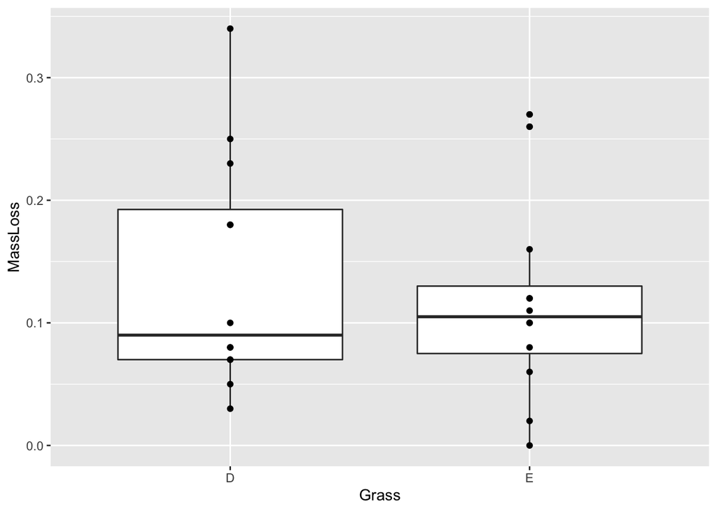

```r
#1. Compare between plant type and look at overall spread of data
ggplot(T3dat)+
  geom_boxplot(aes(Grass, MassLoss))+
  geom_point(aes(Grass, MassLoss))
```

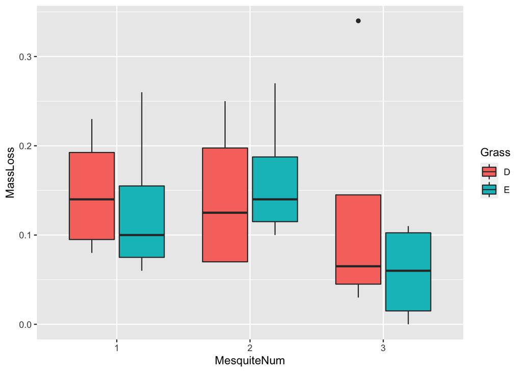

```r
#2. Compare between plot and plant type
ggplot(T3dat, aes(MesquiteNum, MassLoss, fill=Grass))+
  geom_boxplot()
```

### Look at overall trends in mass loss between site and grass type

Takeaways: Treatments of interest are IC (invasive canopy), and NC (native canopy)  
IC: DICA > ERLE  
NC: ERLE > DICA

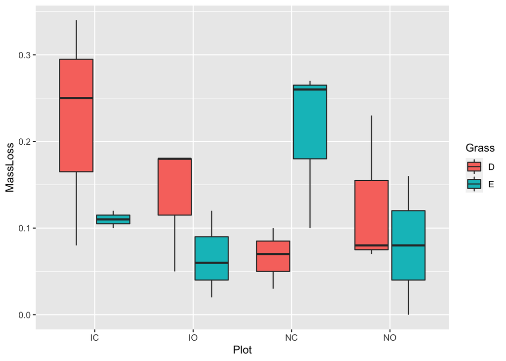

```r
#Compare between treatment and grass
ggplot(T3dat,aes(Plot, MassLoss, fill= Grass))+
  geom_boxplot()
```

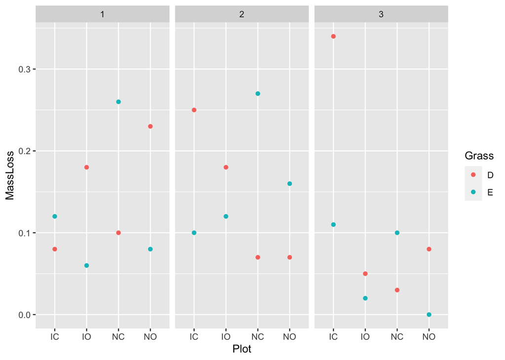

```r
  #geom_point(aes(color=Grass))

#Look at all data seperated  by mesquite#
ggplot(T3dat,aes(Plot, MassLoss, color= Grass))+
  geom_point()+
  facet_wrap(~MesquiteNum)
```

### Quick look at IC and NC for statistical significance : t.test

Takeaway: Neither plot treatment causes significant differences in mass loss between grass species  
IC: p=0.2751  
NC: p=0.1081

```r
# IC: invasive canopy
T3.IC<- T3dat%>%
  dplyr::filter(Plot=="IC")

t.test(MassLoss~Grass, data=T3.IC)
```

```
##
##  Welch Two Sample t-test
##
## data:  MassLoss by Grass
## t = 1.4825, df = 2.0229, p-value = 0.2751
## alternative hypothesis: true difference in means between group D and group E is not equal to 0
## 95 percent confidence interval:
##  -0.2120507  0.4387173
## sample estimates:
## mean in group D mean in group E
##       0.2233333       0.1100000
```

```r
#not sig

# NC: native canopy
T3.NC<- T3dat%>%
  dplyr::filter(Plot=="NC")

t.test(MassLoss~Grass, data=T3.NC)
```

```
##
##  Welch Two Sample t-test
##
## data:  MassLoss by Grass
## t = -2.4422, df = 2.5323, p-value = 0.1081
## alternative hypothesis: true difference in means between group D and group E is not equal to 0
## 95 percent confidence interval:
##  -0.3512228  0.0645561
## sample estimates:
## mean in group D mean in group E
##      0.06666667      0.21000000
```

```r
#not sig
```

### ANOVA: looking at Mass loss as a function of Plot*Grass type

Takeaway: Interaction effect of plot and grass type on Mass loss is marginally significant (p=0.0585)

```r
plot<-aov(MassLoss~ Plot*Grass, data=T3dat)
summary(plot)
```

```
##             Df  Sum Sq  Mean Sq F value Pr(>F)
## Plot         3 0.01742 0.005806   0.920 0.4534
## Grass        1 0.00282 0.002817   0.446 0.5135
## Plot:Grass   3 0.05788 0.019294   3.059 0.0585 .
## Residuals   16 0.10093 0.006308
## ---
## Signif. codes:  0 '***' 0.001 '**' 0.01 '*' 0.05 '.' 0.1 ' ' 1
```

### ANOVA: looking at Mass Loss as a function of plot, looking at each grass separately

Takeaway: No plot treatment effect when filtering by grass species ERLE: p=0.11 DICA: p=0.276

```r
T3.ERLE<- T3dat %>%
  dplyr::filter(Grass== "E")
T3.DICA<- T3dat %>%
  dplyr::filter(Grass== "D")

plot.grass.ERLE<- aov(MassLoss~ Plot, data=T3.ERLE)
summary(plot.grass.ERLE)
```

```
##             Df  Sum Sq  Mean Sq F value Pr(>F)
## Plot         3 0.03780 0.012600   2.779   0.11
## Residuals    8 0.03627 0.004533
```

```r
plot.grass.DICA<- aov(MassLoss~ Plot, data=T3.DICA)
summary(plot.grass.DICA)
```

```
##             Df  Sum Sq  Mean Sq F value Pr(>F)
## Plot         3 0.03750 0.012500   1.546  0.276
## Residuals    8 0.06467 0.008083
```